# jekyll-jupyter-notebook20250118-3503-wyrzwl

This project focuses on using satellite imagery to understand environmental conditions in great detail. We're using advanced computer vision techniques to analyze this imagery, looking for signs of drought stress. By training our algorithms on a carefully labeled dataset, we aim to identify patterns that indicate if droughts are likely to occur.

**Dataset**

The current dataset consists of 86,317 train and 10,778 validation satellite images, 65x65 pixels each, in 10 spectrum bands, with 10,774 images withheld to test long-term generalization (107,869 total). Human experts (pastoralists) have labeled these with the number of cows that the geographic location at the center of the image could support (0, 1, 2, or 3+ cows). Each pixel represents a 30 meter square, so the images at full size are 1.95 kilometers across. Pastoralists are asked to rate the quality of the area within 20 meters of where they are standing, which corresponds to an area slightly larger a single pixel. Since forage quality is correlated across space, the larger image may be useful for prediction.

The data is in TFRecords format, split into train and val, and takes up ~4.3GB (2.15GB zipped). You can learn more about the format of the satellite images here.

The data used in this research was collected through a research collaboration between the International Livestock Research Institute, Cornell University, and UC San Diego. It was supported by the Atkinson Centre for a Sustainable Future’s Academic Venture Fund, Australian Aid through the AusAID Development Research Awards Scheme Agreement No. 66138, the National Science Foundation (0832782, 1059284, 1522054), and ARO grant W911-NF-14-1-0498.

**Downloading the Data**

```python
!echo "Downloading data"
!curl -SL https://storage.googleapis.com/wandb_datasets/dw_train_86K_val_10K.zip > dw_data.zip
!unzip dw_data.zip
!rm dw_data.zip
!mv droughtwatch_data/ data/
```

[output not shown]

[output cut: 455 more lines]

[output not shown]

**Visualizing data**

```python
import os
import matplotlib.pyplot as plt
import numpy as np
import tensorflow as tf
```

The dataset is in the form of TFRecordDataset. In a TFRecord dataset, data is serialized into a binary format, which reduces storage space and speeds up data reading and processing. Each record in the dataset contains a serialized example, which typically includes features and labels for machine learning tasks.

```python
import os
import tensorflow as tf

# Define a lambda function to generate a list of file paths
dirlist = lambda di: [os.path.join(di, file) for file in os.listdir(di) if 'part-' in file]

# Get a list of training file paths
training_files = dirlist('data/val/')

# Define a function to parse TFRecord data
def parse_visual(data):
    # Create a TFRecordDataset from the input data file
    dataset = tf.data.TFRecordDataset(data)

    # Define the features expected in the TFRecord examples
    features = {
        'B2': tf.io.FixedLenFeature([], tf.string),  # Blue band data
        'B3': tf.io.FixedLenFeature([], tf.string),  # Green band data
        'B4': tf.io.FixedLenFeature([], tf.string),  # Red band data
        'label': tf.io.FixedLenFeature([], tf.int64),  # Label or target value
    }

    # Parse each TFRecord example in the dataset using the defined features
    parsed_examples = [tf.io.parse_single_example(data, features) for data in dataset]
    return parsed_examples

# Parse TFRecord examples from the first training file
parsed_examples = parse_visual(training_files[0])
```

```python
def get_img_from_example(parsed_example, intensify=True):
    # Initialize an empty RGB array with dimensions 65x65x3
    rgbArray = np.zeros((65,65,3), 'uint8')

    # Iterate over each band (B4, B3, B2)
    for i, band in enumerate(['B4', 'B3', 'B2']):
        # Extract band data from the parsed example and convert it to numpy array
        band_data = np.frombuffer(parsed_example[band].numpy(), dtype=np.uint8)
        # Reshape the band data to match the dimensions of a 65x65 image
        band_data = band_data.reshape(65, 65)


        if intensify:
            band_data = band_data/np.max(band_data)*255
        else:
            band_data = band_data*255

        # Assign the band data to the corresponding channel in the RGB array
        rgbArray[..., i] = band_data

    # Extract the label from the parsed example and convert it to numpy array
    label = tf.cast(parsed_example['label'], tf.int32).numpy()

    return rgbArray, label
```

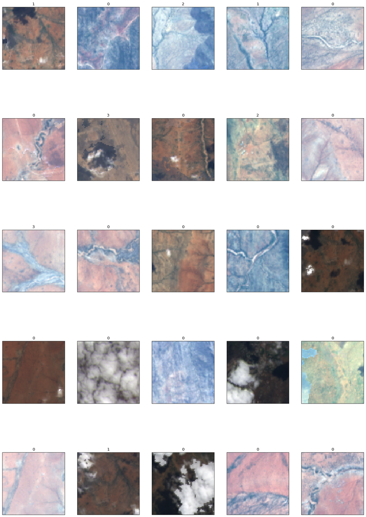

```python
fig=plt.figure(figsize=(20, 30), dpi= 80, facecolor='w', edgecolor='k')
for i in range(1,26):
    plt.subplot(5, 5, i)
    img, label = img, label = get_img_from_example(parsed_examples[i+7])
    plt.imshow(img).axes.get_xaxis().set_visible(False)
    plt.imshow(img).axes.get_yaxis().set_visible(False)
    plt.title(str(label))

fig.show()
```

**Defining constants**

```python
# Total size of the dataset
TOTAL_TRAIN = 86317
TOTAL_VAL = 10778

# Sample size of dataset for training purpose
SIZE= 0.1 # modify this only
SIZE_TRAIN = int(TOTAL_TRAIN*SIZE)
SIZE_VAL = int(TOTAL_VAL)

# Parameters of the data (do not change)
IMG_DIM = 65
NUM_CLASSES = 4
```

**Defining features**

The satellite imagery data contains different spectral bands. These bands represent different wavelengths of light captured by the satellite sensor, each providing unique information about the Earth's surface.

B1 30 meters 0.43 - 0.45 µm Coastal aerosol

B2 30 meters 0.45 - 0.51 µm Blue

B3 30 meters 0.53 - 0.59 µm Green

B4 30 meters 0.64 - 0.67 µm Red

B5 30 meters 0.85 - 0.88 µm Near infrared

B6 30 meters 1.57 - 1.65 µm Shortwave infrared 1

B7 30 meters 2.11 - 2.29 µm Shortwave infrared 2

B8 15 meters 0.52 - 0.90 µm Band 8 Panchromatic

B9 15 meters 1.36 - 1.38 µm Cirrus

B10 30 meters 10.60 - 11.19 µm Thermal infrared 1, resampled from 100m to 30m

B11 30 meters 11.50 - 12.51 µm Thermal infrared 2, resampled from 100m to 30m

We create a dictionary 'features' which defines the structure of the data stored in TFRecord format. The need to do this arises because:

**Data Structure Definition**: The TFRecord format is a binary storage format used in TensorFlow for efficiently handling large datasets. However, it's a generic format that doesn't inherently understand the structure of the data it contains. By creating this dictionary, we explicitly define the structure of the data that will be stored in TFRecord files. Each key-value pair in the dictionary represents a feature name and its corresponding properties, such as data type and shape.

**Parsing**: When reading data from TFRecord files during training or inference, TensorFlow needs to know how to interpret the binary data stored in each example. The dictionary serves as a blueprint for parsing the TFRecord examples correctly. TensorFlow uses this dictionary to decode the binary data into tensors that can be fed into the machine learning model.

**Consistency and Compatibility**: Defining the data structure upfront ensures consistency and compatibility between the data stored in TFRecord files and the model's input requirements. It ensures that the features expected by the model match the features stored in the TFRecord files, preventing data parsing errors and mismatches during training or inference.

**Integration with TensorFlow APIs**: TensorFlow provides high-level APIs for working with TFRecord datasets, such as tf.data.TFRecordDataset and tf.io.parse_single_example. These APIs rely on the feature dictionary to understand how to read and parse the data correctly.

```python
features = {
  'B1': tf.io.FixedLenFeature([], tf.string),
  'B2': tf.io.FixedLenFeature([], tf.string),
  'B3': tf.io.FixedLenFeature([], tf.string),
  'B4': tf.io.FixedLenFeature([], tf.string),
  'B5': tf.io.FixedLenFeature([], tf.string),
  'B6': tf.io.FixedLenFeature([], tf.string),
  'B7': tf.io.FixedLenFeature([], tf.string),
  'B8': tf.io.FixedLenFeature([], tf.string),
  'B9': tf.io.FixedLenFeature([], tf.string),
  'B10': tf.io.FixedLenFeature([], tf.string),
  'B11': tf.io.FixedLenFeature([], tf.string),
  'label': tf.io.FixedLenFeature([], tf.int64),
}
```

**Extracting training and validation data**

```python
import os
import tensorflow as tf

def get_data(train_data_size, val_data_size, local=True):

    def load_data_local(data_path):
        train = file_list_from_folder("train", data_path)
        val = file_list_from_folder("val", data_path)
        return train, val

    def file_list_from_folder(folder, data_path):
        folderpath = os.path.join(data_path, folder)
        filelist = []
        for filename in os.listdir(folderpath):
            if filename.startswith('part-') and not filename.endswith('gstmp'):
                filelist.append(os.path.join(folderpath, filename))
        return filelist

    def parse_tfrecords(filelist, batch_size, buffer_size, include_viz=False):
        # try a subset of possible bands
        def _parse_(serialized_example, keylist=['B1', 'B4', 'B3', 'B2', 'B5', 'B6', 'B7', 'B8', 'B9', 'B10', 'B11']):
            example = tf.io.parse_single_example(serialized_example, features)

            def getband(example_key):
                img = tf.io.decode_raw(example_key, tf.uint8)
                return tf.reshape(img[:IMG_DIM**2], shape=(IMG_DIM, IMG_DIM, 1))

            bandlist = [getband(example[key]) for key in keylist]
            # combine bands into tensor
            image = tf.concat(bandlist, -1)

            # one-hot encode ground truth labels
            label = tf.cast(example['label'], tf.int32)
            label = tf.one_hot(label, NUM_CLASSES)

            return {'image': image}, label

        tfrecord_dataset = tf.data.TFRecordDataset(filelist)
        tfrecord_dataset = tfrecord_dataset.map(lambda x:_parse_(x)).shuffle(buffer_size).repeat(-1).batch(batch_size)
        tfrecord_iterator = iter(tfrecord_dataset)
        image, label = tfrecord_iterator.get_next()
        return image, label

    if local:
        data_path = "/content/data/"
        train_tfrecords, val_tfrecords = load_data_local(data_path)

    X_train, y_train = parse_tfrecords(train_tfrecords, train_data_size, train_data_size)
    X_val, y_val = parse_tfrecords(val_tfrecords, val_data_size, val_data_size)

    return X_train, X_val, y_train, y_val



X_train_total, X_val_total, y_train_total, y_val_total = get_data(SIZE_TRAIN, SIZE_VAL, local=True)
```

The holdout fucntion implements a holdout strategy for splitting a dataset into training, validation, and test sets.

```python
def holdout(X_train_total, X_val_total, y_train_total, y_val_total, proportion=(2/3)):
    '''Hold out function'''

    k = int(proportion * SIZE_TRAIN) # Modify this only

    X_train, y_train = X_train_total["image"][:k], y_train_total[:k]
    X_val, y_val = X_train_total["image"][k:], y_train_total[k:]
    X_test, y_test = X_val_total["image"], y_val_total

    return X_train, y_train, X_val, y_val, X_test, y_test
X_train, y_train, X_val, y_val, X_test, y_test = holdout(X_train_total, X_val_total, y_train_total, y_val_total)
```

**Cleaning the data**

```python
import numpy as np

def clean_data(X,y):
    ''' Delete empty images (std < 10) '''
    def find_empty_images(X):
        empty_images = []
        X = np.array(X)
        for i in range(X.shape[0]):
            if X[i].std() < 10:
                empty_images.append(i)
        return empty_images
    X = np.array(X)
    y = np.array(y)
    empty_imgs = find_empty_images(X)
    new_index = [i for i in range(X.shape[0]) if i not in empty_imgs]
    X = np.take(X,new_index,axis=0)
    y = np.take(y,new_index,axis=0)
    return X,y

X_train, y_train = clean_data(X_train, y_train)
X_val, y_val = clean_data(X_val, y_val)
X_test, y_test = clean_data(X_test, y_test)
```

when working with multi-channel image data, such as satellite imagery, selecting specific channels can help focus the model's attention on relevant information, reduce computational complexity, and improve model performance by discarding irrelevant or redundant channels. Here we define a function to select specific channels from a dataset of images and returns a modified dataset containing only the selected channels.

```python
def dataset_select_channels(train_images,list_of_channels):
    ''' Input a dataset and a list of channels as a list:
    Example: dataset_select_channels(train_images,['B4','B3','B2']) to convert
    images to RGB.
    '''
    channels_index = [features_list.index(i) for i in list_of_channels]
    data = np.array(train_images)
    return data[:,:,:,channels_index]

features_list = [ 'B1', 'B4', 'B3', 'B2', 'B5', 'B6', 'B7', 'B8', 'B9', 'B10', 'B11']
 # Select features
list_of_channels = ['B7', 'B6', 'B5'] # Modify this for each model, full_list_of_channels = ['B1','B4', 'B3', 'B2', 'B5', 'B6', 'B7','B8','B9','B10','B11']
X_train = dataset_select_channels(X_train, list_of_channels)
X_val = dataset_select_channels(X_val, list_of_channels)
X_test = dataset_select_channels(X_test, list_of_channels)
```

In this project we use efficientNet model for classification of satellite images. EfficientNet introduces a novel compound scaling method that uniformly scales the network's depth, width, and resolution in a principled way. This allows EfficientNet to efficiently balance model complexity and computational resources, resulting in better performance across different scales.

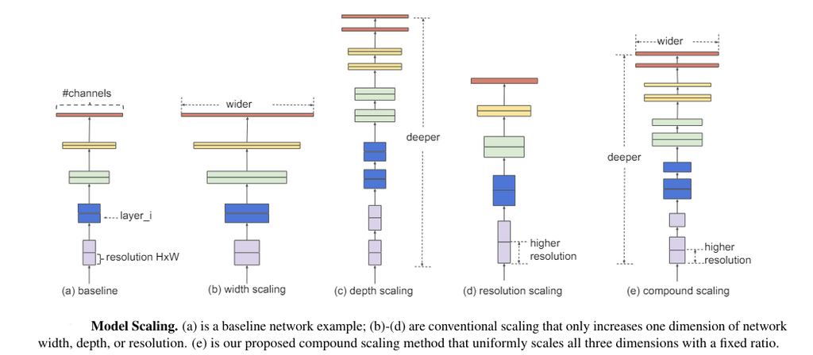

```python
import os
import sys
import argparse
import math
import pandas as pd
import numpy as np

import tensorflow.compat.v1 as tf
from tensorflow.keras import optimizers
from tensorflow.keras import layers, initializers
from tensorflow.keras import models
from tensorflow.keras.callbacks import EarlyStopping
from tensorflow.keras.applications.vgg16 import VGG16
from tensorflow.keras.applications.vgg16 import preprocess_input
from tensorflow.keras.layers.experimental.preprocessing import Resizing
from tensorflow.keras.applications import EfficientNetB3

from termcolor import colored
from google.cloud import storage
from keras.models import model_from_json

def efficientnet_model():
    ''' Transfer learning model that takes X_train with ['B7','B6','B5']'''

    IMG_SIZE = 65
    inputs = layers.Input(shape=(IMG_SIZE, IMG_SIZE, 3))

    x = inputs
    x = Resizing(65, 65)(x)

    activationnetB3 = EfficientNetB3(include_top=False, weights = "imagenet")(x)

    outputsflatten = layers.Flatten()(activationnetB3)

    outputsdense1 = layers.Dense(64, activation = "relu")(outputsflatten)
    outputsdense2 = layers.Dense(64, activation = "relu")(outputsdense1)

    outputsdense3 = layers.Dense(4, activation = "softmax")(outputsdense2)

    model = tf.keras.Model(inputs, outputsdense3)

    model.compile(optimizer="adam",
                loss="categorical_crossentropy",
                metrics=["accuracy"])

    return model
```

```python
def train_efficient_net(X_train, X_val, y_train, y_val):
    '''Function to fit Efficient Net model'''

    es = EarlyStopping(monitor='val_loss', patience=20, verbose=1, restore_best_weights=True)

    datagen = tf.keras.preprocessing.image.ImageDataGenerator()
    datagen.fit(X_train)

    X_val = Resizing(65, 65, interpolation="bilinear")(X_val)

    history = model.fit(datagen.flow(X_train, y_train, batch_size=16),
                        epochs=50,
                        validation_data = (X_val, y_val),
                        verbose = 1,
                        callbacks=[es])

    return history
```

```python
history =train_efficient_net(X_train, X_val, y_train, y_val)
```

Accuracy achieved in the classification task using effcientNet model:

```python
results = model.evaluate(X_test,y_test,verbose=1)
print(f'The accuracy of the model is:{results[1]}')
print(results)
```

```
The accuracy of the model is:0.45342081785202026
[1.2502360343933105, 0.45342081785202026]
```

References:

- Tan, M., & Le, Q. V. (2020). EfficientNet: Rethinking Model Scaling for Convolutional Neural Networks. arXiv preprint arXiv:1905.11946.
- Hobbs, A., & Svetlichnaya, S. (2020). Satellite-based Prediction of Forage Conditions for Livestock in Northern Kenya. arXiv preprint arXiv:2004.04081.
- https://github.com/wandb/droughtwatch